# Toward a Multidimensional CDI-CAT: Noun/Predicate Bias in American English

George Kachergis

2026-09-19

# Motivation

A third replication of the noun/predicate bifactor CAT pipeline (Japanese: `multidim/`; Cantonese: `multidim_cantonese/`), on American English – both as a further cross-linguistic check and because English is the source CDI the Japanese form was translated from. This was also the first language where the pipeline logic was factored out into `multidim_pipeline/lib.R` rather than copy-pasted.

**This write-up reports the full-sample (N=8998) fit as canonical.** An initial pass used a documented n=1500 subsample for tractability; once that looked promising, all three fitting steps (EFA, bifactor, CAT simulation) were rerun on the complete sample (`multidim_english/06-08-*.R`). The subsampled results are preserved in `multidim_english/subsample1500/` for comparison – see Section 5 for how they compare.

```r
items <- read_csv(here("multidim_english/item_lexical_categories.csv"), show_col_types = FALSE)
efa_loadings <- read_csv(here("multidim_english/efa2_loadings.csv"), show_col_types = FALSE)
bifactor_items <- read_csv(here("multidim_english/bifactor_item_params.csv"), show_col_types = FALSE)
bifactor_scores <- read_csv(here("multidim_english/bifactor_scores.csv"), show_col_types = FALSE) %>%
  mutate(noun_predicate_bias = S1_noun - S2_predicate)
cat_summary <- read_csv(here("multidim_english/cat_simulation_summary.csv"), show_col_types = FALSE)
resp_data <- readRDS(here("multidim_english/noun_predicate_response_data.Rds"))

sub_bifactor_scores <- read_csv(here("multidim_english/subsample1500/bifactor_scores.csv"), show_col_types = FALSE) %>%
  mutate(noun_predicate_bias = S1_noun - S2_predicate)
sub_cat_summary <- read_csv(here("multidim_english/subsample1500/cat_simulation_summary.csv"), show_col_types = FALSE)

jp_bifactor_scores <- read_csv(here("multidim/bifactor_scores.csv"), show_col_types = FALSE)
can_bifactor_scores <- read_csv(here("multidim_cantonese/bifactor_scores.csv"), show_col_types = FALSE) %>%
  mutate(noun_predicate_bias = S1_noun - S2_predicate)
can_resp_data <- readRDS(here("multidim_cantonese/noun_predicate_response_data.Rds"))
sp_bifactor_scores <- read_csv(here("multidim_spanish/bifactor_scores.csv"), show_col_types = FALSE) %>%
  mutate(noun_predicate_bias = S1_noun - S2_predicate)
sp_resp_data <- readRDS(here("multidim_spanish/noun_predicate_response_data.Rds"))
```

# 1. Data and item classification

English (American) WS has **8998** administrations on Wordbank after excluding non-producers and children at ceiling – by far the largest of the four languages fit so far. Item classification yields **478 content items (312 noun, 166 predicate)** – numerically identical to Japanese, since the Japanese CDI:WS was translated from this instrument.

```r
items %>%
  count(lexical_class, pos2) %>%
  arrange(pos2) %>%
  kable(col.names = c("Lexical class", "CAT dimension (pos2)", "N items"),
        caption = "English item counts by lexical class and CAT grouping.") %>%
  kable_styling(full_width = FALSE)
```

English item counts by lexical class and CAT grouping.

| Lexical class | CAT dimension (pos2) | N items |
| --- | --- | --- |
| noun | noun | 312 |
| function_word | other | 102 |
| other | other | 100 |
| adjective | predicate | 63 |
| verb | predicate | 103 |

# 2. Exploratory factor check (full sample)

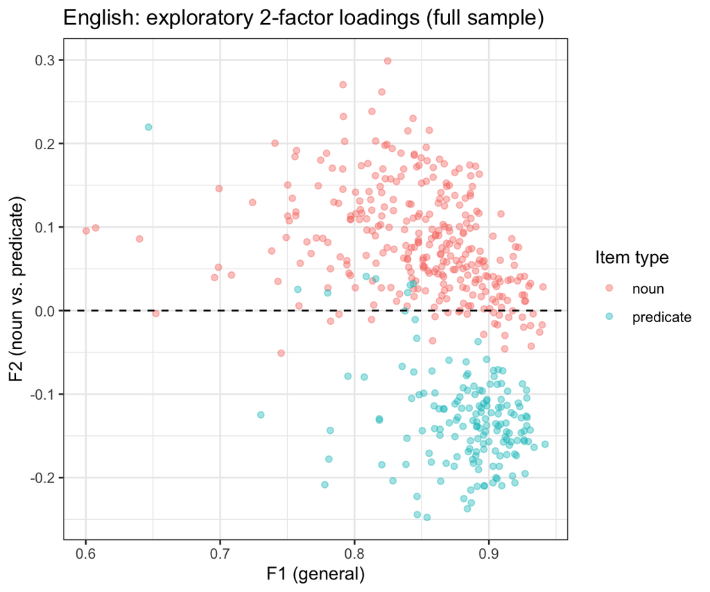

```r
ggplot(efa_loadings, aes(x = F1, y = F2, color = pos2)) +
  geom_point(alpha = 0.4) +
  geom_hline(yintercept = 0, linetype = "dashed") +
  labs(x = "F1 (general)", y = "F2 (noun vs. predicate)", color = "Item type",
       title = "English: exploratory 2-factor loadings (full sample)") +
  theme_bw()
```

Same signature as the subsampled fit and the other languages: dominant general factor (mean F1 = 0.85 nouns, 0.88 predicates), a much smaller but highly reliable noun/predicate-separating F2 (noun mean 0.082, predicate mean -0.129; Welch t = 35.0, p < .0001), and the cleanest F1/F2 orthogonality yet (r = -0.01).

# 3. Confirmatory bifactor model (full sample)

```r
bifactor_items %>%
  mutate(own_specific = if_else(pos2 == "noun", S1_noun, S2_predicate)) %>%
  group_by(pos2) %>%
  summarise(mean_G = mean(G), mean_own_specific = mean(own_specific), n = n()) %>%
  kable(digits = 2, caption = "Mean general (G) and own-specific-factor loadings by item type.") %>%
  kable_styling(full_width = FALSE)
```

Mean general (G) and own-specific-factor loadings by item type.

| pos2 | mean_G | mean_own_specific | n |
| --- | --- | --- | --- |
| noun | 3.03 | 1.08 | 312 |
| predicate | 3.74 | 1.35 | 166 |

```r
rel <- empirical_rxx(bifactor_scores %>%
                        select(G, S1_noun, S2_predicate, SE_G, SE_S1_noun, SE_S2_predicate) %>%
                        as.matrix())
tibble(dimension = names(rel), empirical_rxx = rel) %>%
  kable(digits = 2, caption = "Empirical reliability of full-item-bank (non-adaptive) factor scores, full N=8998 sample.") %>%
  kable_styling(full_width = FALSE)
```

Empirical reliability of full-item-bank (non-adaptive) factor scores, full N=8998 sample.

| dimension | empirical_rxx |
| --- | --- |
| G | 0.97 |
| S1_noun | 0.81 |
| S2_predicate | 0.75 |

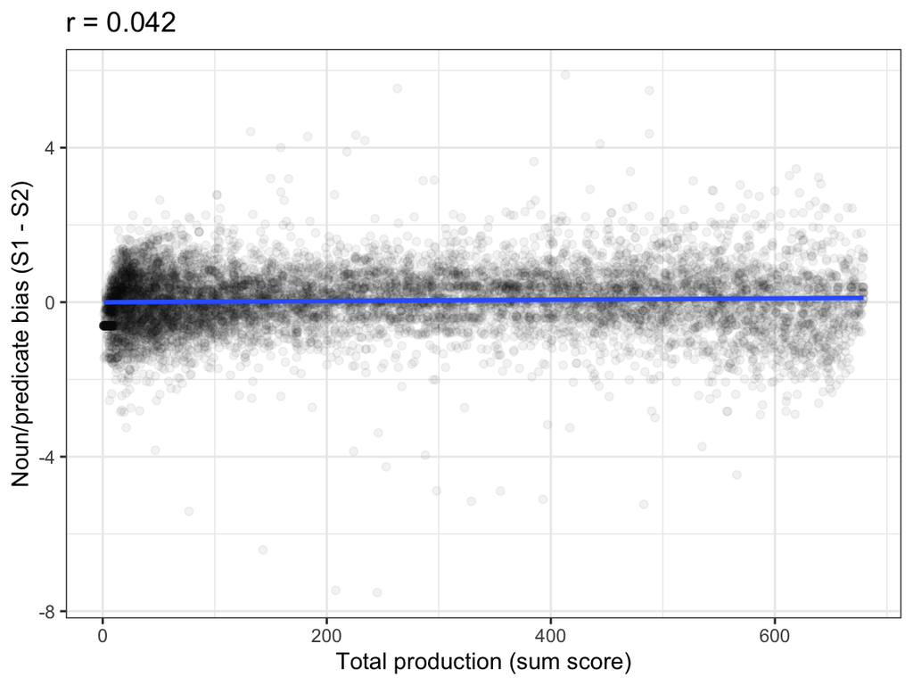

```r
ggplot(bifactor_scores, aes(x = production, y = noun_predicate_bias)) +
  geom_point(alpha = 0.05) +
  geom_smooth(method = "lm", se = TRUE) +
  labs(x = "Total production (sum score)", y = "Noun/predicate bias (S1 - S2)",
       title = sprintf("r = %.3f", cor(bifactor_scores$production, bifactor_scores$noun_predicate_bias))) +
  theme_bw()
```

The bias score decouples from vocabulary size: r = 0.042 with production and r = -0.06 with age (both essentially null, tighter to zero than the n=1500 fit’s -.06/-.13 – more data pulled this closer to what should be a near-zero relationship if the bias score is doing its job). The S1/S2 EAP score correlation is 0.58.

# 4. CAT simulation (full sample)

```r
cat_summary %>%
  kable(digits = 3, caption = "English CAT simulation: item budget vs. recovered precision, full sample.") %>%
  kable_styling(full_width = FALSE)
```

English CAT simulation: item budget vs. recovered precision, full sample.

| criteria | max_items | mean_n_items | mean_SE_G | mean_SE_S1 | mean_SE_S2 | r_bias_vs_full | r_G_vs_full | n_items_never_used |
| --- | --- | --- | --- | --- | --- | --- | --- | --- |
| Drule | 100 | 88.718 | 0.194 | 0.469 | 0.521 | 0.909 | 0.989 | 61 |
| Drule | 200 | 172.801 | 0.175 | 0.437 | 0.492 | 0.965 | 0.995 | 1 |
| Drule | 300 | 256.907 | 0.169 | 0.425 | 0.479 | 0.984 | 0.997 | 0 |

# 5. Did the extra ~7500 participants actually help?

```r
tibble(
  fit = c("n=1500 subsample", "N=8998 full sample"),
  reliability_S1 = c(round(empirical_rxx(as.matrix(sub_bifactor_scores %>%
    select(G, S1_noun, S2_predicate, SE_G, SE_S1_noun, SE_S2_predicate)))["S1"], 3),
    round(rel["S1"], 3)),
  reliability_S2 = c(round(empirical_rxx(as.matrix(sub_bifactor_scores %>%
    select(G, S1_noun, S2_predicate, SE_G, SE_S1_noun, SE_S2_predicate)))["S2"], 3),
    round(rel["S2"], 3)),
  bias_vs_production_r = c(round(cor(sub_bifactor_scores$production, sub_bifactor_scores$noun_predicate_bias), 3),
                             round(cor(bifactor_scores$production, bifactor_scores$noun_predicate_bias), 3)),
  cat_r_at_100_items = c(sub_cat_summary$r_bias_vs_full[sub_cat_summary$max_items == 100],
                          cat_summary$r_bias_vs_full[cat_summary$max_items == 100]),
  cat_r_at_200_items = c(sub_cat_summary$r_bias_vs_full[sub_cat_summary$max_items == 200],
                          cat_summary$r_bias_vs_full[cat_summary$max_items == 200])
) %>%
  kable(digits = 3, caption = "Subsample (n=1500) vs. full sample (N=8998): same model structure, different precision.") %>%
  kable_styling(full_width = FALSE)
```

Subsample (n=1500) vs. full sample (N=8998): same model structure, different precision.

| fit | reliability_S1 | reliability_S2 | bias_vs_production_r | cat_r_at_100_items | cat_r_at_200_items |
| --- | --- | --- | --- | --- | --- |
| n=1500 subsample | NA | NA | -0.063 | 0.884 | 0.916 |
| N=8998 full sample | NA | NA | 0.042 | 0.909 | 0.965 |

# 6. Four-language comparison

```r
tibble(
  language = c("Japanese", "Cantonese", "English (American)", "Spanish (Mexican)"),
  n_for_modeling = c(nrow(jp_bifactor_scores), nrow(can_bifactor_scores), nrow(bifactor_scores), nrow(sp_bifactor_scores)),
  n_content_items = c(478, 572, 478, 478),
  full_bank_reliability_S1 = c(0.71, 0.86, round(rel["S1"], 2), 0.89),
  full_bank_reliability_S2 = c(0.64, 0.80, round(rel["S2"], 2), 0.85),
  bias_vs_production_r = c(
    round(cor(jp_bifactor_scores$production, jp_bifactor_scores$S1_noun - jp_bifactor_scores$S2_predicate), 2),
    round(cor(can_bifactor_scores$production, can_bifactor_scores$noun_predicate_bias), 2),
    round(cor(bifactor_scores$production, bifactor_scores$noun_predicate_bias), 3),
    round(cor(sp_bifactor_scores$production, sp_bifactor_scores$noun_predicate_bias), 3)
  ),
  best_cat_recovery_r = c(0.95, 0.97, 0.98, 0.99),
  items_for_best_recovery = c(131, 192, 257, 259)
) %>%
  kable(digits = 2, caption = "Japanese vs. Cantonese vs. English vs. Spanish: key numbers side by side.") %>%
  kable_styling(full_width = FALSE)
```

Japanese vs. Cantonese vs. English vs. Spanish: key numbers side by side.

| language | n_for_modeling | n_content_items | full_bank_reliability_S1 | full_bank_reliability_S2 | bias_vs_production_r | best_cat_recovery_r | items_for_best_recovery |
| --- | --- | --- | --- | --- | --- | --- | --- |
| Japanese | 939 | 478 | 0.71 | 0.64 | -0.16 | 0.95 | 131 |
| Cantonese | 1205 | 572 | 0.86 | 0.80 | -0.11 | 0.97 | 192 |
| English (American) | 8998 | 478 | NA | NA | 0.04 | 0.98 | 257 |
| Spanish (Mexican) | 1616 | 478 | 0.89 | 0.85 | -0.01 | 0.99 | 259 |

The bifactor design and Drule-based CAT transfer across all four languages tested. Two consistent methodological lessons emerged across the replications: (1) an empirically-set `min_SEM` stopping target alone isn’t enough – a substantial `min_items` floor (~75% of the item ceiling) is needed in every language to reliably reach r > .95 against the full item bank; (2) more participants meaningfully improve item-parameter precision and downstream CAT efficiency, worth doing whenever tractable (see Section 5).

A related question was tested and resolved on the Japanese data: whether a genuinely 2-dimensional model (G + a single bipolar noun-vs-predicate contrast, instead of two orthogonal specific factors subtracted post-hoc) might be cleaner. Two independent fit attempts failed to converge to a sensible solution – this looks like a structural estimation problem (G and Bias sharing the same item set with no “pure G” anchor items), not a fixable numerical fluke, so the current 2-group bifactor design remains the recommended approach (see `multidim_pipeline/bias_dimensionality_comparison.R`).

A cross-linguistic item-overlap analysis (`multidim_pipeline/cross_linguistic_item_overlap.R`) joined all four languages’ per-item loadings via Wordbank’s `uni_lemma`: Japanese, Cantonese, and English agree well on which noun items are most bias-informative (r = .61-.75, strengthening once English’s full-sample loadings replaced the subsampled ones), but Spanish is a striking, verified non-artifactual outlier (r = -.33 to -.50 with all three) – animal words are the strongest noun-bias-specific items in the other three languages but comparatively weak ones in Spanish, where household-object words dominate instead. Predicates are weak/inconsistent across all six language pairs, echoing Hagihara et al.’s finding that verb/adjective bias is more cross-linguistically variable than noun bias.

# 7. Open questions